# Conant_QTW_TimeSeries

## Case Study 8 - Time Series - Stock Data

### Stacy Conant

#### March 2, 2020

## Contents

- Introduction
- Data
- Method
  - Differenced Data
  - Manual Model Selection
  - Grid Search
- Conclusions
- References

Back to Top

## Introduction

ARIMA, or ‘AutoRegressive Integrated Moving Average’, is a forecasting algorithm based on the idea that information from the past values of the time series can alone be used to predict the future values. Economic data, such as stock price, is notoriously tricky to analyze and forecast as there are many factors that can influence the economy. In this case study, two years of British Petroleum (BP) closing stock price data will be analyzed using ARIMA rules and AIC to decide the best fitting model. Then the analysis will be repeated using a grid search. The forecasts from each model will then be compared using the average square error (ASE). R will be used for this analysis, especially the `tswge` and `fpp2` packages.

Back to Top

## Data

```r
#load necessary librarys
library(quantmod)
options("getSymbols.warning4.0"=FALSE)
library(tswge)
library(ggplot2)
options(warn=-1)
library(tseries)
library(fpp2)
```

#### To pull the data, the `getSymbols` function from the `quantmod` package is used. For this analysis, the closing stock prices for BP are used. The time range is set for two years, February 2018 to Feb 2020.

```r
#quantmod package - pull data
getSymbols("BP",from = "2018-2-1", to = "2020-2-3", auto.assign=TRUE)
```

'BP'

```r
#Summary of data
summary(BP)
```

```
     Index               BP.Open         BP.High          BP.Low
 Min.   :2018-02-01   Min.   :35.92   Min.   :36.09   Min.   :35.73
 1st Qu.:2018-08-01   1st Qu.:39.05   1st Qu.:39.23   1st Qu.:38.70
 Median :2019-02-01   Median :41.28   Median :41.47   Median :40.96
 Mean   :2019-01-31   Mean   :41.38   Mean   :41.61   Mean   :41.08
 3rd Qu.:2019-08-01   3rd Qu.:43.71   3rd Qu.:43.99   3rd Qu.:43.49
 Max.   :2020-01-31   Max.   :47.38   Max.   :47.83   Max.   :47.38
    BP.Close       BP.Volume         BP.Adjusted
 Min.   :36.05   Min.   : 2348400   Min.   :33.88
 1st Qu.:38.95   1st Qu.: 4712150   1st Qu.:36.81
 Median :41.22   Median : 5975500   Median :38.47
 Mean   :41.33   Mean   : 6525950   Mean   :38.45
 3rd Qu.:43.80   3rd Qu.: 7845700   3rd Qu.:40.03
 Max.   :47.79   Max.   :19987200   Max.   :42.95
```

```r
#get number of values/days
close = BP$BP.Close
nrow(close)
```

503

#### The data pulled by `quantmod` includes open, high, low, and adjusted prices, but for this study only the closing price will be analyzed. The mean closing price is \$41.33 and there are 503 observations.

Back to Top

## Method

To analyze this stock data, the time series should be stationary. Stationarity has three conditions:

1. Subpopulations of $𝑋_𝑡$ have the same mean for each $t$. Restated, the mean does not depend on time ($t$).
2. Subpopulations of $X$ for a given time have a finite and constant variance for all t. Restated, the variance does not depend on time.
3. The correlation of $𝑋_𝑡1$ and $𝑋_𝑡2$ depends only on $𝑡_2− 𝑡_1$. That is, the correlation between data points is dependent only on how far apart they are, not where they are.

Stationary data should be a "flat looking" series, without trend, with constant variance over time, a constant autocorrelation structure over time and no periodic seasonality. There are tools in R that can assist in assessing the stationarity of a time series.

For this analysis, the R package `tswge` will be primarily used to explore and model the data. First, the BP closing price time series will be plotted with `plotts.wge()`.

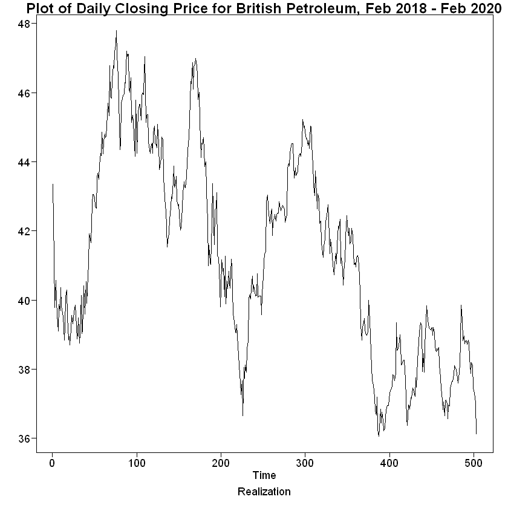

```r
#plot time series
plotts.wge(close)
title("Plot of Daily Closing Price for British Petroleum, Feb 2018 - Feb 2020")
```

#### Figure 1: Plot of Daily Closing Price for British Petroleum. It appears to have a wandering pattern with a few larger jumps in price.

Next, looking at the spectral density can give clues about the frequencies that may be present in this time series. The `parzen.wge()` function calculates and plots the smoothed periodogram using the Parzen window. Before the plot, it outputs the frequencies at which the smoothed periodogram is calculated (`freq`) and the smoothed periodogram point using the Parzen window (`pzgram`).

1. 0.00198807157057654

2. 0.00397614314115308

3. 0.00596421471172962

4. 0.00795228628230616

5. 0.0099403578528827

6. 0.0119284294234592

7. 0.0139165009940358

8. 0.0159045725646123

9. 0.0178926441351889

10. 0.0198807157057654

11. 0.0218687872763419

12. 0.0238568588469185

13. 0.025844930417495

14. 0.0278330019880716

15. 0.0298210735586481

16. 0.0318091451292246

17. 0.0337972166998012

18. 0.0357852882703777

19. 0.0377733598409543

20. 0.0397614314115308

21. 0.0417495029821074

22. 0.0437375745526839

23. 0.0457256461232604

24. 0.047713717693837

25. 0.0497017892644135

26. 0.0516898608349901

27. 0.0536779324055666

28. 0.0556660039761431

29. 0.0576540755467197

30. 0.0596421471172962

31. 0.0616302186878728

32. 0.0636182902584493

33. 0.0656063618290258

34. 0.0675944333996024

35. 0.0695825049701789

36. 0.0715705765407555

37. 0.073558648111332

38. 0.0755467196819085

39. 0.0775347912524851

40. 0.0795228628230616

41. 0.0815109343936382

42. 0.0834990059642147

43. 0.0854870775347912

44. 0.0874751491053678

45. 0.0894632206759443

46. 0.0914512922465209

47. 0.0934393638170974

48. 0.095427435387674

49. 0.0974155069582505

50. 0.099403578528827

51. 0.101391650099404

52. 0.10337972166998

53. 0.105367793240557

54. 0.107355864811133

55. 0.10934393638171

56. 0.111332007952286

57. 0.113320079522863

58. 0.115308151093439

59. 0.117296222664016

60. 0.119284294234592

61. 0.121272365805169

62. 0.123260437375746

63. 0.125248508946322

64. 0.127236580516899

65. 0.129224652087475

66. 0.131212723658052

67. 0.133200795228628

68. 0.135188866799205

69. 0.137176938369781

70. 0.139165009940358

71. 0.141153081510934

72. 0.143141153081511

73. 0.145129224652087

74. 0.147117296222664

75. 0.149105367793241

76. 0.151093439363817

77. 0.153081510934394

78. 0.15506958250497

79. 0.157057654075547

80. 0.159045725646123

81. 0.1610337972167

82. 0.163021868787276

83. 0.165009940357853

84. 0.166998011928429

85. 0.168986083499006

86. 0.170974155069582

87. 0.172962226640159

88. 0.174950298210736

89. 0.176938369781312

90. 0.178926441351889

91. 0.180914512922465

92. 0.182902584493042

93. 0.184890656063618

94. 0.186878727634195

95. 0.188866799204771

96. 0.190854870775348

97. 0.192842942345924

98. 0.194831013916501

99. 0.196819085487078

100. 0.198807157057654

101. 0.200795228628231

102. 0.202783300198807

103. 0.204771371769384

104. 0.20675944333996

105. 0.208747514910537

106. 0.210735586481113

107. 0.21272365805169

108. 0.214711729622266

109. 0.216699801192843

110. 0.218687872763419

111. 0.220675944333996

112. 0.222664015904573

113. 0.224652087475149

114. 0.226640159045726

115. 0.228628230616302

116. 0.230616302186879

117. 0.232604373757455

118. 0.234592445328032

119. 0.236580516898608

120. 0.238568588469185

121. 0.240556660039761

122. 0.242544731610338

123. 0.244532803180915

124. 0.246520874751491

125. 0.248508946322068

126. 0.250497017892644

127. 0.252485089463221

128. 0.254473161033797

129. 0.256461232604374

130. 0.25844930417495

131. 0.260437375745527

132. 0.262425447316103

133. 0.26441351888668

134. 0.266401590457256

135. 0.268389662027833

136. 0.27037773359841

137. 0.272365805168986

138. 0.274353876739563

139. 0.276341948310139

140. 0.278330019880716

141. 0.280318091451292

142. 0.282306163021869

143. 0.284294234592445

144. 0.286282306163022

145. 0.288270377733598

146. 0.290258449304175

147. 0.292246520874752

148. 0.294234592445328

149. 0.296222664015905

150. 0.298210735586481

151. 0.300198807157058

152. 0.302186878727634

153. 0.304174950298211

154. 0.306163021868787

155. 0.308151093439364

156. 0.31013916500994

157. 0.312127236580517

158. 0.314115308151093

159. 0.31610337972167

160. 0.318091451292247

161. 0.320079522862823

162. 0.3220675944334

163. 0.324055666003976

164. 0.326043737574553

165. 0.328031809145129

166. 0.330019880715706

167. 0.332007952286282

168. 0.333996023856859

169. 0.335984095427435

170. 0.337972166998012

171. 0.339960238568588

172. 0.341948310139165

173. 0.343936381709742

174. 0.345924453280318

175. 0.347912524850895

176. 0.349900596421471

177. 0.351888667992048

178. 0.353876739562624

179. 0.355864811133201

180. 0.357852882703777

181. 0.359840954274354

182. 0.36182902584493

183. 0.363817097415507

184. 0.365805168986084

185. 0.36779324055666

186. 0.369781312127237

187. 0.371769383697813

188. 0.37375745526839

189. 0.375745526838966

190. 0.377733598409543

191. 0.379721669980119

192. 0.381709741550696

193. 0.383697813121272

194. 0.385685884691849

195. 0.387673956262425

196. 0.389662027833002

197. 0.391650099403579

198. 0.393638170974155

199. 0.395626242544732

200. 0.397614314115308

201. 0.399602385685885

202. 0.401590457256461

203. 0.403578528827038

204. 0.405566600397614

205. 0.407554671968191

206. 0.409542743538767

207. 0.411530815109344

208. 0.41351888667992

209. 0.415506958250497

210. 0.417495029821074

211. 0.41948310139165

212. 0.421471172962227

213. 0.423459244532803

214. 0.42544731610338

215. 0.427435387673956

216. 0.429423459244533

217. 0.431411530815109

218. 0.433399602385686

219. 0.435387673956262

220. 0.437375745526839

221. 0.439363817097416

222. 0.441351888667992

223. 0.443339960238569

224. 0.445328031809145

225. 0.447316103379722

226. 0.449304174950298

227. 0.451292246520875

228. 0.453280318091451

229. 0.455268389662028

230. 0.457256461232604

231. 0.459244532803181

232. 0.461232604373757

233. 0.463220675944334

234. 0.465208747514911

235. 0.467196819085487

236. 0.469184890656064

237. 0.47117296222664

238. 0.473161033797217

239. 0.475149105367793

240. 0.47713717693837

241. 0.479125248508946

242. 0.481113320079523

243. 0.483101391650099

244. 0.485089463220676

245. 0.487077534791252

246. 0.489065606361829

247. 0.491053677932406

248. 0.493041749502982

249. 0.495029821073559

250. 0.497017892644135

251. 0.499005964214712

1. 16.772838980633

2. 16.2804130300713

3. 15.4655306322954

4. 14.3394680899425

5. 12.9235899723269

6. 11.2560143774781

7. 9.40118523874183

8. 7.46091486856595

9. 5.57937884624677

10. 3.92280103864778

11. 2.61455261852462

12. 1.65722171320321

13. 0.928236882161266

14. 0.263550359724702

15. -0.454433984108863

16. -1.25221773329896

17. -2.05326464894426

18. -2.70400678411528

19. -3.06832033262573

20. -3.14276066102779

21. -3.05579940967414

22. -2.95949676424466

23. -2.95264232770598

24. -3.0738933533886

25. -3.32376349841868

26. -3.6870620162321

27. -4.14750534640359

28. -4.69167825573682

29. -5.30216165687236

30. -5.94586701993394

31. -6.57061146176876

32. -7.12210334747956

33. -7.57422388522595

34. -7.93968422372334

35. -8.24010397248525

36. -8.46306139844307

37. -8.55586763587466

38. -8.47666460407302

39. -8.25754183158291

40. -8.00435432941316

41. -7.83655803324915

42. -7.83437529246574

43. -8.02043108437659

44. -8.36065083735745

45. -8.7741853288975

46. -9.16062865195203

47. -9.45034274629949

48. -9.64823139219479

49. -9.8252570303157

50. -10.0647076890436

51. -10.4118409505434

52. -10.8511243707112

53. -11.3098570354503

54. -11.6904485349461

55. -11.9267627401175

56. -12.0237387214262

57. -12.0392544751017

58. -12.033148487768

59. -12.037116811164

60. -12.0599850947725

61. -12.1091547098747

62. -12.2051691014617

63. -12.3783829451447

64. -12.6517970619093

65. -13.0200804368539

66. -13.4321145783132

67. -13.7864400901281

68. -13.9595234940699

69. -13.8758467678216

70. -13.5684819732624

71. -13.1601781570653

72. -12.7912089344433

73. -12.5692062276261

74. -12.5580635457563

75. -12.7827418174628

76. -13.2322569131487

77. -13.8564282118466

78. -14.5621375022977

79. -15.2259892140301

80. -15.7412627803471

81. -16.0793653012469

82. -16.3023072000104

83. -16.5080148982994

84. -16.7643452378501

85. -17.0709515986716

86. -17.3475287879383

87. -17.4580648629926

88. -17.2947446767954

89. -16.8724630428233

90. -16.3189023415657

91. -15.7748488874803

92. -15.3243222495906

93. -14.9896573486603

94. -14.7587574469466

95. -14.6170141639488

96. -14.5679285254408

97. -14.6326079522044

98. -14.8298958180319

99. -15.1490669168999

100. -15.5297173549928

101. -15.8681323217479

102. -16.0693684904563

103. -16.1205621258814

104. -16.1067963344504

105. -16.1492607098927

106. -16.3385219714121

107. -16.7091846328388

108. -17.2423197765399

109. -17.8728163824163

110. -18.4916308226665

111. -18.9492685804453

112. -19.0929957860066

113. -18.86211978889

114. -18.3588231699607

115. -17.7872239955281

116. -17.3347052204913

117. -17.1117892207522

118. -17.1451410471108

119. -17.3791094089647

120. -17.6776409423237

121. -17.8627133121044

122. -17.820020073133

123. -17.5863806952797

124. -17.2967099277124

125. -17.0608820934124

126. -16.9013451568555

127. -16.7645809134903

128. -16.5752953896538

129. -16.3013348410484

130. -15.9803222786664

131. -15.6875042875766

132. -15.4858099672874

133. -15.4003515713002

134. -15.4210282028074

135. -15.5197591263274

136. -15.6693518170235

137. -15.8524157657403

138. -16.0541468592882

139. -16.2456412808584

140. -16.3761459926091

141. -16.3920007902818

142. -16.2774253594852

143. -16.0795955737192

144. -15.8887340387414

145. -15.7938637214101

146. -15.8496325286025

147. -16.0618254712732

148. -16.383144500235

149. -16.7200941116107

150. -16.9660055973877

151. -17.0618667921584

152. -17.0381474392318

153. -16.9893162938786

154. -17.0103734587098

155. -17.1531810453361

156. -17.4146924130013

157. -17.742031873205

158. -18.046618690445

159. -18.2299743890962

160. -18.2210370705358

161. -18.0097327453929

162. -17.6538195570827

163. -17.2539318949409

164. -16.916652290387

165. -16.7268135648599

166. -16.7339981969209

167. -16.9472049640355

168. -17.3323358766924

169. -17.8146379733182

170. -18.2957142308177

171. -18.6887211815998

172. -18.9482414718107

173. -19.0617782937151

174. -19.0171132627711

175. -18.7994997787257

176. -18.4315479652903

177. -17.9996739176678

178. -17.6248810634248

179. -17.410152806823

180. -17.4068784017244

181. -17.6018926735514

182. -17.9140949086896

183. -18.2105849947292

184. -18.3682689060502

185. -18.3605842345937

186. -18.2767087208553

187. -18.2464320413389

188. -18.3590250050362

189. -18.6303193966252

190. -19.0046526100888

191. -19.3816324290244

192. -19.6740210356948

193. -19.872206414636

194. -20.0528439744937

195. -20.3203138543656

196. -20.7384352260115

197. -21.286419070774

198. -21.8364976961457

199. -22.1802133921256

200. -22.1569341854739

201. -21.7967158388447

202. -21.2780500880908

203. -20.7715986299015

204. -20.365923131846

205. -20.0800207379009

206. -19.896341126447

207. -19.7867798407909

208. -19.7286996181756

209. -19.7121292797738

210. -19.7387612432839

211. -19.8133783598748

212. -19.9294547995832

213. -20.0538028390635

214. -20.121769900063

215. -20.0597847328854

216. -19.8352872650179

217. -19.4917008995066

218. -19.1258237304144

219. -18.8310160799687

220. -18.6563340282809

221. -18.5959984437718

222. -18.6011653189642

223. -18.6095075919515

224. -18.5845671374489

225. -18.5400695430221

226. -18.528180346754

227. -18.6038510629099

228. -18.7930631551122

229. -19.0768799446571

230. -19.3904665552673

231. -19.6402522385743

232. -19.7440930944685

233. -19.6773709392895

234. -19.4853452583798

235. -19.2506462957609

236. -19.0511960944803

237. -18.9384459626803

238. -18.9348300323497

239. -19.0379362682099

240. -19.2231879832111

241. -19.4431882391269

242. -19.6283063835854

243. -19.6995491320087

244. -19.6012771543106

245. -19.3365103373485

246. -18.9688263745037

247. -18.5855262075561

248. -18.2569184010669

249. -18.018094317108

250. -17.872309651484

251. -17.8058798397819

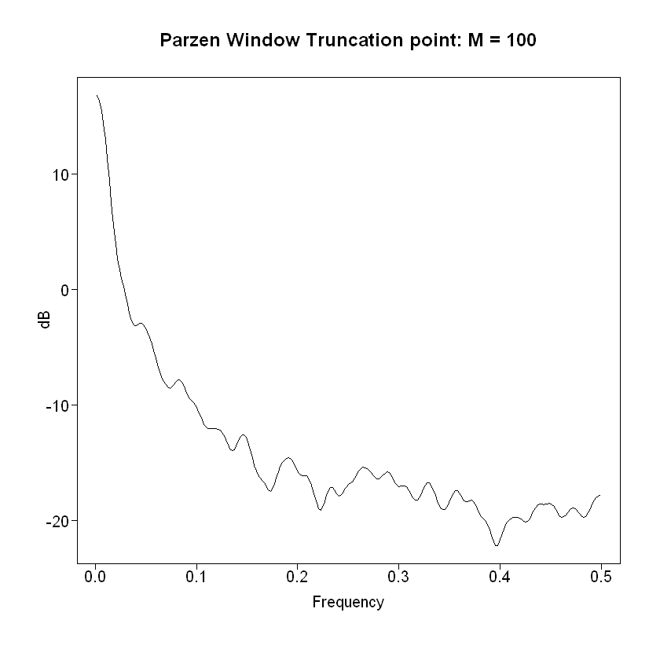

```r
parzen.wge(close, trunc=100)
```

#### Figure 2: Parzen plot of Spectral Density.

The highest frequency in the Parzen Window is at 0, which indicates that this is indeed a wandering time series with no decernible seasonality or trend.

The next task is to check the ACF and PACF. The ACF, or auto-correlation function, gives values of auto-correlation of any series with its lagged values. It is a graphic representation that helps to describe how well the present value of the series is related with its past values.

The PACF, or partial auto-correlation function, finds the correlation of the residuals with the next lag value, hence ‘partial’, and not ‘complete’ as it removes already found variations before it find the next correlation.

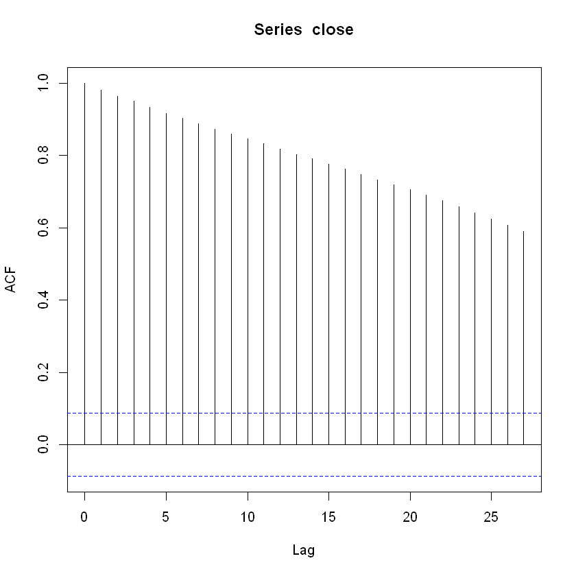

```r
acf(close)
```

#### Figure 3: ACF for Daily BP Closing Stock Price.

This ACF is slowly dampening to zero, even out past 25 lags. This could indicate that future values of the series are correlated / heavily affected by past values and that the stock prices are not stationary.

Altering the lag max in the function to increase the plotted lags displays where the lags begin approach zero.

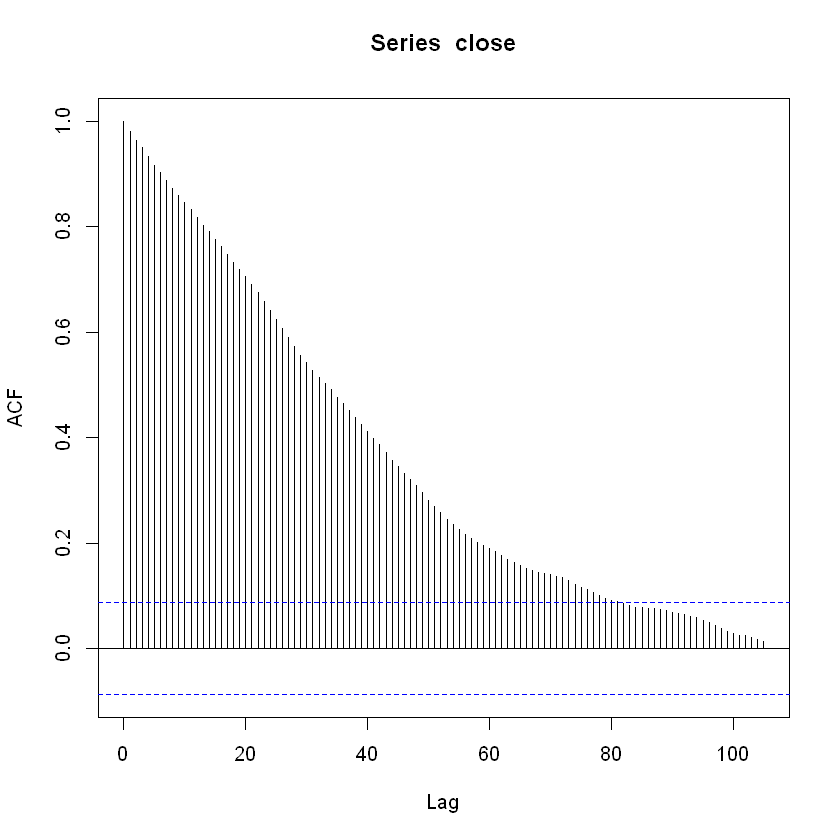

```r
acf(close, lag.max = 105)
```

#### Figure 4: ACF to lag 105 for Daily BP Closing Stock Price.

There is good positive correlation with the lags up to about lag 80, this is the point where ACF plot cuts the upper confidence threshold.

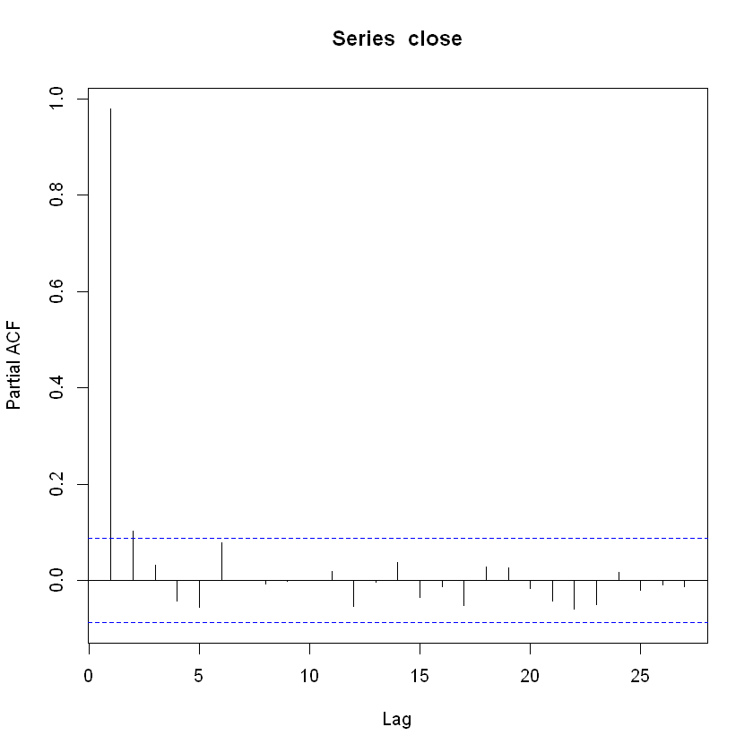

```r
pacf(close)
```

#### Figure 5: PACF for Daily BP Closing Stock Price.

The PACF displays the lag crossing the 95% limit line and approaching zero at lag 2. This could indicate an AR(2) process in this data.

A test that can be conducted to look for stationarity is the Augmented Dickey–Fuller (ADF) t-statistic test to find if the series has a unit root (a series with a trend line, or non-stationary, will have a unit root and result in a large p-value). The `adt.test()` function from the `tseries` package will be used.

```r
#test for stationarity
adf.test(close)
```

```
	Augmented Dickey-Fuller Test

data:  close
Dickey-Fuller = -2.694, Lag order = 7, p-value = 0.2846
alternative hypothesis: stationary
```

The Dickey-Fuller for stationarity fails to reject the null and indicates that the BP stock data is not stationary with a p-value of 0.2846.

Back to Top

## Differenced Data

To attempt to stationarize the data, one difference can be taken. Differencing can help stabilise the mean of a time series by computing the differences between consecutive observations to eliminate or reduce any trend and seasonality. To do this, `tswge` has the `artrans.wge()` function.

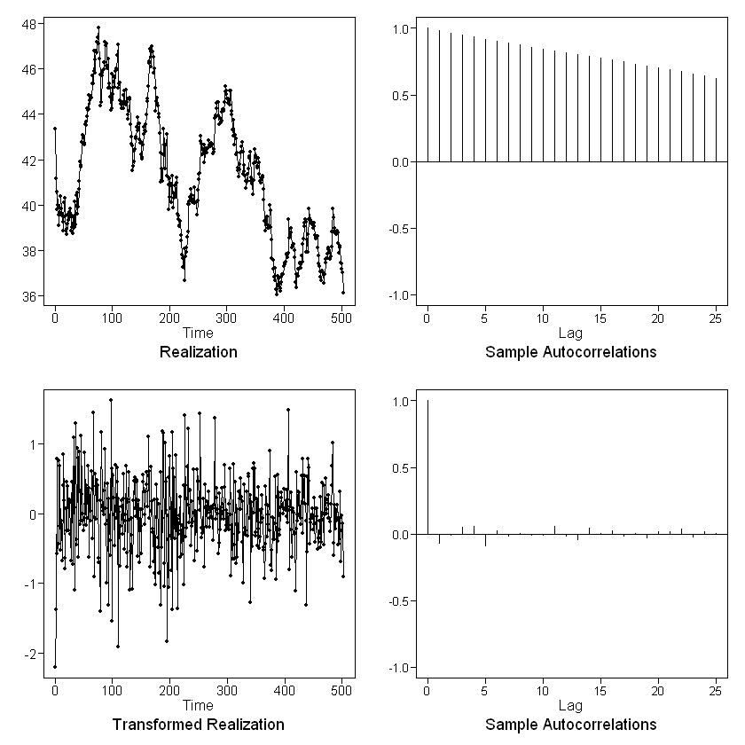

```r
#take 1 difference with artrans
close.dif = artrans.wge(close, 1)
```

#### Figure 6: Plots of orginal time series and ACF (top) and differenced time series and ACF (bottom).

The transformed times series certainly appears more stationary. The ACF for the transformed data now appears as a white noise series. Another Dickey-Fuller test can assess the stationary of this difference data.

```r
#stationarity test of differenced data
adf.test(close.dif)
```

```
	Augmented Dickey-Fuller Test

data:  close.dif
Dickey-Fuller = -7.9607, Lag order = 7, p-value = 0.01
alternative hypothesis: stationary
```

The test for stationarity on the differenced data rejects the null and indicates that the BP stock data is stationary with a p-value of 0.01.

Another test for stationarity is the Jlung-Box test for independence. The Ljung-Box test examines whether there is significant evidence for non-zero correlations at given lags, with the null hypothesis of independence in a given time series (a non-stationary signal will have a low p-value). The `jlung.wge()` function of `tswge` is used for this test.

```r
ljung.wge(close.dif)
```

```
Obs -0.07141393 -0.008923918 0.04868184 0.05578057 -0.08628334 0.02453343 -0.01434213 0.002765201 -0.008621435 -0.006807761 0.05791577 -0.01510345 -0.04470057 0.04159326 0.002429646 0.02486328 -0.01619557 0.006486719 -0.02650535 0.01441494 0.01414213 0.03533125 -0.02384849 0.01602258
```

**$test**

'Ljung-Box test'

**$K**

24

**$chi.square**

15.60342289125

**$df**

24

**$pval**

0.901855815289356

The p-value of the test on the differenced time series has a large p-value indicating that the time series is stationary.

Back to Top

### Manual Model Search

Next, the ACF and PACF of the differenced data can be assessed to attempt to determine the $p$ and $q$ terms for the ARIMA model. The `acf()` and `pacf()` functions are used for this.

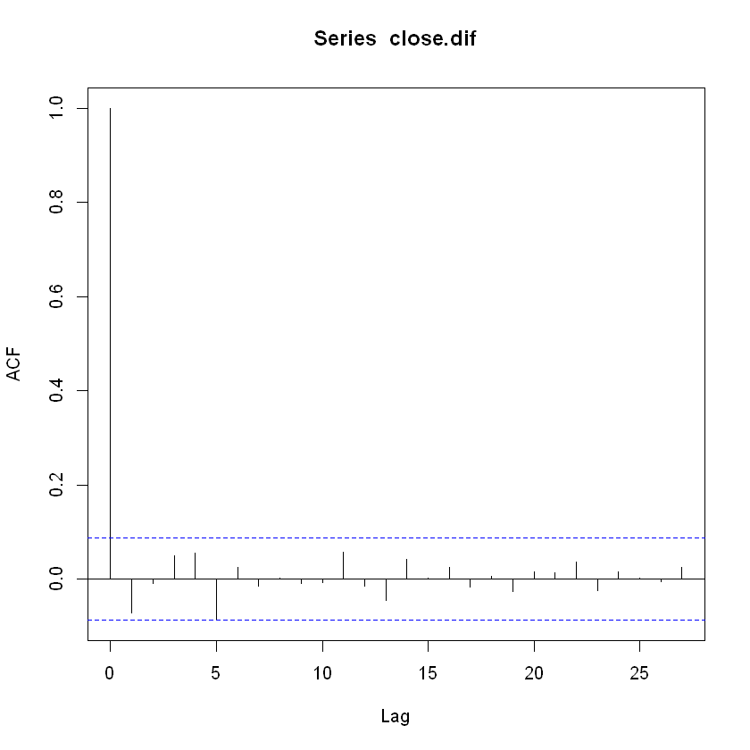

```r
#plot acf of differenced data
acf(close.dif)
```

#### Figure 7: Plot of the differenced time series ACF.

The ACF can help to determine the value of $q$ for the MA process. All of the lags are within the 95% confidence intervals. This could mean that 0 may be an apropriate MA term, but an MA term of 1 or 2 is also plausible. Rule 7 indicates that a negative lag 1 in the ACF, as shown in Fig. 7, could mean that the series is slightly "overdifferenced" and an MA term should be added to the model.

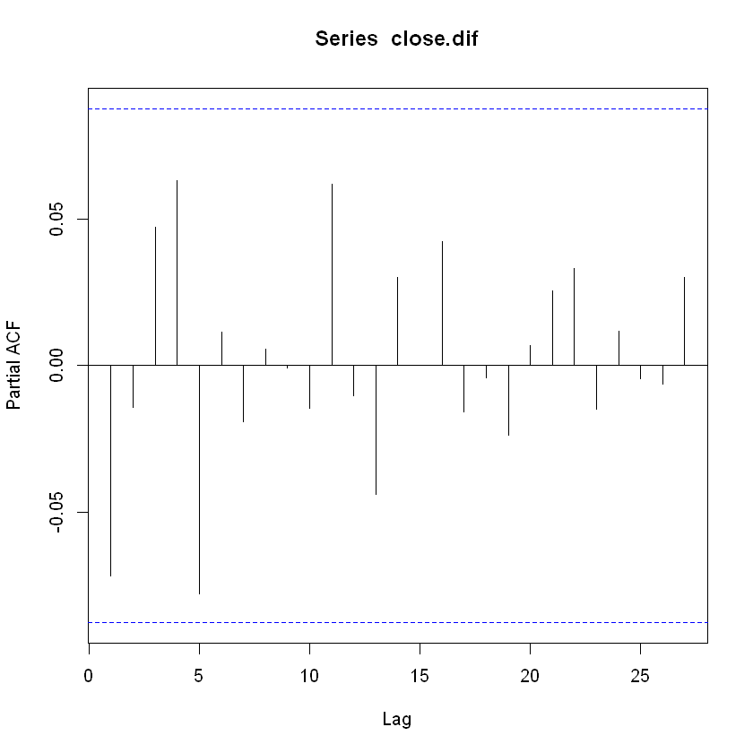

```r
#plot pacf of differenced data
pacf(close.dif)
```

#### Figure 8: Plot of the differenced time series PACF.

The PACF can be assessed for the AR term, or $p$. Here again, all the of the lags are within the 95% limit lines. Conservatively, 0 could be used as the AR term, but rule 6 indicated that 1 or 2 may be more likely to give a better model.

Several models can be tried and judged in terms of AIC score. The Akaike Information Criterion (AIC) is an estimator of overall model quality and widely used for model selection. It measures the relative information loss by a given model. Thus, less information loss by a model, better the model quality.

$AIC$ = 2$\textit{k}$ - 2ln$({\widehat{L}})$

The function `est.arma.wge()` is used to calculate maximum likelihood estimates of parameters of stationary models. The $p$ and $q$ terms are plugged in to the function along with the differenced data. The AIC can be printed for the model.

```r
#model 1 - AR(2) and MA(2)
dif.est1 = est.arma.wge(close.dif, p=2, q=2)
#print AIC
dif.est1$aic
```

```
Coefficients of Original polynomial:
-0.1317 -0.8183

Factor                 Roots                Abs Recip    System Freq
1+0.1317B+0.8183B^2   -0.0805+-1.1025i      0.9046       0.2616
```

-1.28453096636655

```r
#model 2 - AR(2) and MA(1)
dif.est2 = est.arma.wge(close.dif, p=2, q=1)
#print AIC
dif.est2$aic
```

```
Coefficients of Original polynomial:
-0.3278 -0.0411

Factor                 Roots                Abs Recip    System Freq
1+0.3278B+0.0411B^2   -3.9830+-2.9051i      0.2028       0.3997
```

-1.26951496486221

```r
#model 3 - AR(1) and MA(2)
dif.est3 = est.arma.wge(close.dif, p=1, q=2)
#print AIC
dif.est3$aic
```

```
Coefficients of Original polynomial:
0.5969

Factor                 Roots                Abs Recip    System Freq
1-0.5969B              1.6753               0.5969       0.0000
```

-1.27086594941382

#### The lowest AIC is the first model, an ARIMA(2,1,2).

To fuller assess this model's appropriateness, the ACF of the residuals of the estimate can be viewed and tested for whiteness using the Jlung-Box test again.

```
Obs -0.001238373 0.02357949 -0.01260141 0.03958959 -0.03265358 0.02737353 -0.0591823 0.0009563824 0.02623148 -0.004441566 0.02961887 -0.01142664 -0.0234686 0.03268989 -0.009071479 0.03756145 -0.004747382 -0.008058259 -0.03768635 0.0256482 0.02613063 0.03129668 -0.0295573 0.01725465
```

0.99758910091187

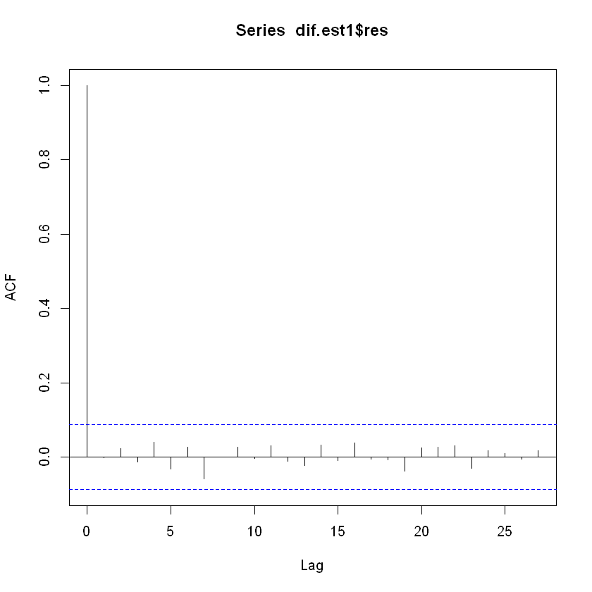

```r
#print pval of the Jlung-Box test of the residuals
ljung.wge(dif.est1$res)$pval
#view ACF
acf(dif.est1$res)
```

#### Figure 9: Plot of the residuals of the ARIMA(2,1,2) model.

The ACF of the residuals show the lags staying completely withing the 95% limit lines and the Jlung-Box test returns a large p-value. Both of these indicate that the model does not exhibit any significant lack of fit and forecasting could be performed.

Calling `dif.est1` displays the data output by the estimate, including phi and theta terms.

```r
#display estimate data
dif.est1
```

**$phi**

1. -0.131705494787098

2. -0.818270945091426

**$theta**

1. -0.058987572259534

2. -0.793412552735592

1. -1.8885399143342

2. -1.53215660742561

3. 0.424904183017137

4. -0.376514708988139

5. -0.165468569015401

6. -0.629103635457036

7. 0.530303560070368

8. 0.0560000571354485

9. 0.882208805961413

10. -0.656114215603534

11. -0.36654917191723

12. 0.0076182992996029

13. -0.554731192718225

14. 0.293376101359371

15. 0.798482479951524

16. 0.385658992202769

17. -0.697638682458714

18. -0.825322889471043

19. -0.020444846302116

20. -0.0690425559681614

21. 0.542228156214026

22. 0.305078835681294

23. -0.232351335686394

24. 0.237250580409219

25. 0.221813123182491

26. 0.165840751644937

27. -0.269007749695408

28. -0.651669371709304

29. 0.10491863986532

30. 0.45358772243333

31. -0.621724526831332

32. 0.266954882106652

33. 1.03647828084281

34. -0.964003988266217

35. 0.0996327207632204

36. 1.19881291328305

37. -0.326816196056205

38. -0.269309464957135

39. 0.826322407279121

40. -0.615945064889349

41. 0.895004405291044

42. 0.373841481727189

43. 0.882685286838026

44. -0.101529203358621

45. -0.0590708597457392

46. 1.08802867577183

47. 0.356458278011931

48. 0.0971425466899544

49. -0.131348852093519

50. -0.294410656901625

51. -0.0337720664200627

52. 0.938059921876043

53. 0.198166918447283

54. -0.159356966191151

55. 0.382423725296806

56. 0.376858720983786

57. 0.0113847210606692

58. 0.669219462104861

59. -0.618143592729759

60. 0.377029166169253

61. 0.239508833484989

62. -0.0547639421629195

63. 0.0299501931805441

64. 0.601893607168308

65. 0.423703882062744

66. -0.289213816690184

67. 1.39794979377578

68. -0.828511982951741

69. -0.0142379483087327

70. 0.51324863432872

71. 0.433264001086306

72. 0.0330866712737663

73. 0.47096366983035

74. 0.161809263558545

75. 0.472665459944687

76. -0.618707197824834

77. -0.707140242161941

78. -0.796395999406434

79. -1.37977283137356

80. 0.174168918554502

81. 1.16198108415538

82. 0.240924172459278

83. 0.163803517137472

84. -0.0295484041589014

85. 0.316959353443105

86. 0.0990244668062661

87. 0.959479309475799

88. -0.154095315436447

89. 0.0876471292185722

90. -0.975211786793233

91. -0.160177090480593

92. 0.408520371725512

93. -1.21230191643322

94. 0.174790267853405

95. -0.263325061110419

96. -0.331390983536557

97. -0.55845690516855

98. 1.54580313015057

99. -1.43760729374703

100. 0.659194724555339

101. 0.505289074215003

102. 0.309575858725515

103. 0.0792636513496216

104. -0.495326913102547

105. 0.625649209349199

106. 0.199965546235594

107. 0.0458506695204354

108. 0.600646524427609

109. 0.444104564899117

110. -1.78534721046905

111. 0.107703731619003

112. -0.0769904547661952

113. -0.628357368797166

114. -0.146177092935981

115. -0.283473543250281

116. 0.171605828248357

117. 0.220610320609359

118. -0.242442689264336

119. 0.480984435907078

120. 0.249843030526219

121. -0.382884621642548

122. -0.0547094798756334

123. -0.184855093649186

124. 0.732859140073168

125. -0.420745629222272

126. -0.805886522006007

127. 0.0511188833610657

128. 0.228925556510797

129. 0.748750081940452

130. -0.0790854445689188

131. -1.19039397039156

132. -0.597467535897074

133. -0.273421247922618

134. -0.034440801847144

135. -1.09583513084325

136. 0.110532394842963

137. 0.222302683124281

138. 0.577771465309221

139. 0.114995622227337

140. 0.478015214903966

141. 0.00259442287761481

142. 0.548900369643642

143. 0.474135423854383

144. -0.593352379286744

145. 0.104783001434842

146. 0.20065540433654

147. -0.635488521522906

148. -0.190352313135152

149. 0.00965195395311359

150. -0.514478393553439

151. -0.155203339841672

152. 0.0153125780491068

153. 0.570937039561489

154. 0.565108355985027

155. 0.370576099729256

156. -0.184907000983589

157. -0.0424355331550941

158. 0.363737092491557

159. 0.486079719501295

160. 0.617980144639591

161. 0.127346643104944

162. 0.576212392293611

163. 1.14731940193369

164. 0.0381579779920656

165. 0.617731488288549

166. -0.77738758721756

167. 0.651559343564156

168. 0.104613987138894

169. 0.23847055612096

170. -0.232547750874384

171. -0.299089667269953

172. -0.675347528007671

173. 0.193410114674369

174. -0.845756694903534

175. -1.04509602111103

176. 0.342714501309399

177. 0.00774058972103765

178. 0.292801753456265

179. -0.359903321928166

180. -0.555437752416736

181. 0.135466477053889

182. -0.781727902258028

183. -0.871993993395716

184. -1.42458958546773

185. 0.54408498648426

186. -0.356634120612233

187. -0.0261365803829446

188. 1.08241039091775

189. 1.24310698780851

190. -0.50570044344183

191. -1.12401958986306

192. 0.778175666559971

193. 0.197827060210435

194. 0.682042894330426

195. -1.90892687197932

196. -0.304567608585988

197. -0.318956690337209

198. -0.844729353338343

199. 0.408607832134855

200. 0.705319834351269

201. -0.122898358843441

202. 0.1927396771398

203. -0.957086349240333

204. 1.05908197630402

205. -1.1719115116974

206. 0.672548530422078

207. -0.336700584761106

208. 0.5303724084039

209. -0.199407811178766

210. -0.132872308424535

211. 0.722436279463528

212. -0.144849994867385

213. -1.24082298429658

214. -0.239301733224531

215. -0.236700324812568

216. -0.141987251135926

217. 0.0415065017980782

218. 0.137044742414345

219. -0.635873395165866

220. -0.179727999097719

221. -0.595241913333765

222. -0.24647733022787

223. -0.380277700993725

224. 0.465604094253516

225. -0.982789120434471

226. 1.32779154293082

227. -0.249411127672199

228. 0.499609270693666

229. -0.230851396967784

230. 0.614958065946683

231. 0.311374426487995

232. 1.31901816193398

233. 0.173932130737699

234. -0.143291316564817

235. 0.317792988176219

236. 0.400114649997336

237. -0.392846499136997

238. 0.131425122880487

239. -0.20067213741801

240. -0.0607768232062802

241. 0.0377966405712152

242. 0.607195234547966

243. -0.626558567229277

244. 0.04923320070171

245. -0.0388515375911057

246. 0.0227254319194149

247. -0.490612971316123

248. 0.597873648287759

249. 0.493180161780241

250. 0.552046065213196

251. 0.268078627493372

252. 0.0214678209143141

253. 1.43072760844662

254. 0.375909053486928

255. -0.270143274199643

256. -0.328989985820252

257. -0.324047436150033

258. 0.309508864206891

259. 0.285471151824734

260. -0.803511725451539

261. 0.347594327902329

262. 0.160344809243029

263. 0.198368196004572

264. -0.214020717851268

265. 0.110121431752409

266. 0.108313259614765

267. 0.0900150266842628

268. 0.299067501677955

269. -0.200643891614644

270. -0.0305411700282991

271. 0.0843870260826492

272. 0.0979642523237162

273. -0.0223843306744335

274. -0.0417601503323462

275. -0.373644379850205

276. 0.0559325384851133

277. 0.150829064197495

278. 1.42739733492391

279. 0.231024636767828

280. -0.0612220464354793

281. 0.306055807263793

282. 0.271872289170673

283. 0.162271553001167

284. -0.00109100451845905

285. -0.63150298919905

286. -0.43019015664549

287. 0.314591510870854

288. -0.18463510538793

289. 0.0363827734906659

290. 0.0794960349686295

291. 0.409112645340063

292. 0.203253894690365

293. 0.0126979606198384

294. -0.0993689589640338

295. 0.393331958157855

296. 0.768311857960217

297. -0.166174559822918

298. 0.0194787078635519

299. -0.201019945192484

300. -0.156991119296019

301. 0.0313876670216857

302. -0.202861442815747

303. 0.130122476434634

304. -0.185669677213477

305. 0.670062569578086

306. 0.0132771280062386

307. -0.865090408086601

308. -0.235006330861663

309. -0.672328156402497

310. -0.260516704789649

311. 0.716815965867129

312. -0.601288178822055

313. -0.459814870576402

314. 0.391136191698367

315. -0.0891221012912028

316. -0.638523289967293

317. -0.0197951932694879

318. -0.667202100567757

319. -0.100734737460492

320. -0.241871386784294

321. 0.283972171237526

322. 0.24445075893586

323. 0.589177904655416

324. 0.10657094396947

325. 0.219558640544682

326. 0.181283023292249

327. -0.348033370806427

328. -1.0101130893753

329. 0.31660390377646

330. -0.2321078695181

331. -0.1126268244765

332. -0.277888179744952

333. -0.379608541493894

334. 0.353742193304801

335. 0.41688751268603

336. -0.293177896085279

337. 0.504315332816312

338. 0.574170437434487

339. 0.0703063737998513

340. 0.254161117043312

341. -1.33753962139377

342. 0.1094938239799

343. -0.253467839706602

344. -0.42374448372486

345. 0.578621020619081

346. 0.0398588146239449

347. 0.811661617497072

348. 0.691591050721548

349. -0.253247055541312

350. -0.337560480420804

351. 0.205846988001099

352. -0.409106913172943

353. 0.0883324648848052

354. 0.361594978138647

355. -0.167818842449012

356. -0.466942009686339

357. -0.38709749983011

358. 0.0188003664235115

359. -0.0593430290088476

360. 0.310462532567425

361. 0.046036837551466

362. -0.062120928291302

363. -0.484902284494166

364. -0.49979076857385

365. -0.97642620346911

366. -0.473033561002265

367. 0.401753965109803

368. 0.191021341547152

369. 0.15299286236459

370. -0.348505154355295

371. -0.168009770938077

372. 0.0147146971709352

373. 0.14646189370463

374. 0.914075323482991

375. -0.183494454445337

376. -0.722813507946524

377. -0.605721926249326

378. -0.856705294780885

379. -0.0242917299060402

380. -0.0283313509289719

381. -0.36978543900408

382. -0.395452277813811

383. -0.146689831808683

384. 0.559298404511868

385. -0.873280858874577

386. -0.264273839571527

387. 0.179712024336779

388. 0.64693222964836

389. -0.282518070269094

390. 0.237011696984912

391. -0.2795374457367

392. -0.238287296765391

393. 0.124897677115609

394. 0.267964726971252

395. 0.25634225029511

396. 0.196128992830196

397. 0.0171401078388894

398. -0.0303462410440101

399. 0.376275196404285

400. 0.137377828391158

401. 0.103920879852371

402. 0.0225873112673989

403. 0.356348275993848

404. 0.0348347432719014

405. -0.113758920388478

406. 0.157303859883425

407. 1.50902729418289

408. -0.637154383681341

409. 0.0227454394583739

410. -0.0239439578551908

411. 0.365536347549757

412. -0.0831460231667694

413. -0.671838274827695

414. -0.0974991277479994

415. 0.136642063612542

416. 0.150644256252293

417. -0.292431241734459

418. -0.391568796734324

419. -1.08592497455603

420. -0.200677624740478

421. 0.554251406183514

422. 0.0422983394158966

423. -0.0327007112905325

424. 0.295101206646038

425. -0.0130596178872149

426. 0.355246586398312

427. 0.00882029693464186

428. -0.0740779530756531

429. -0.165179724309739

430. 0.577751361285519

431. -0.205242549292805

432. 0.784966825735593

433. 0.259554162440557

434. 0.618017421060799

435. 0.204515251684371

436. 0.135483719586877

437. -0.110990858792344

438. -1.28279504403861

439. 0.459272835533301

440. -0.533353171093103

441. 0.846398590109737

442. 0.715325696082604

443. 0.517707221287629

444. -0.398041818642966

445. -0.11123876573397

446. -0.141936807193929

447. 0.00213290461027701

448. 0.00892808588273648

449. 0.0705007780377298

450. -0.218987064118407

451. 0.250232541998235

452. -0.12083656956659

453. -0.404878523719906

454. -0.168901752048625

455. 0.085355564079961

456. 0.0130326723803826

457. 0.0997903409940982

458. -0.520339306860613

459. -0.382104788294255

460. -0.341266434779688

461. -0.0979736907245979

462. -0.478071705265993

463. 0.219475994052466

464. -0.384897072871485

465. 0.459038181161329

466. 0.0388468283575872

467. -0.0670594423453729

468. -0.452450987141151

469. 0.375065648070735

470. 0.0294028667358086

471. 0.553440756626007

472. 0.171597920346784

473. 0.067748762273184

474. 0.0185840961288457

475. 0.222329266146763

476. 0.286568375365839

477. -0.0373237416223778

478. -0.0535484713923346

479. -0.12432428607271

480. -0.247000663422062

481. 0.148863221793096

482. 0.420960064428863

483. 0.742388969197263

484. 1.08847670949239

485. -0.346192518908257

486. -0.635786659904385

487. 0.0475631298824613

488. -0.164116806005477

489. 0.137422944002005

490. -0.0019238083438465

491. -0.139108242494969

492. 0.169695854268346

493. -0.0144441748519712

494. -0.458545815585642

495. -0.489952422705455

496. 0.314629220768641

497. 0.0103668713177734

498. -0.659532649959547

499. -0.119391674927083

500. -0.250153191291754

501. -0.058588787182633

502. -0.884808286500733

**$avar**

0.271321372289188

**$aic**

-1.28453096636655

**$aicc**

-0.280208860849224

**$bic**

-1.24251303688755

**$se.phi**

1. 0.0170644788585324

2. 0.0263467889100477

**$se.theta**

1. 0.0198434265366474

2. 0.0290305029623824

#### Next, the estimates from model 1, (ARIMA(2,1,2), are used to create a forecast. In this case, the phi, theta and difference ($d$) term are included. The forecast will be for 30 days and will begin from 30 days before the end of the series so that comparisons can be made against the actual values.

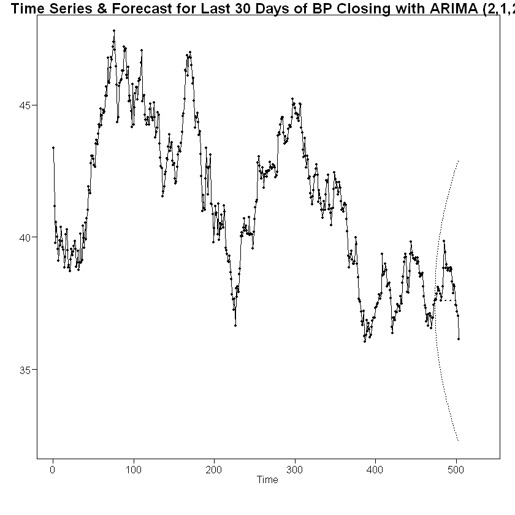

```r
#forecast in tswge for model 1 - ARIMA(2,1,2)
dif.fore1 = fore.aruma.wge(close, phi = dif.est1$phi, theta = dif.est1$theta, d = 1, n.ahead = 30, lastn = T, limits = T)
title("Time Series & Forecast for Last 30 Days of BP Closing with ARIMA (2,1,2)")
```

#### Figure 10: Plot of Forecasts for Last 30 Days of BP Closing Stock Price with ARIMA (2,1,2).

#### The forecast does not do a great job of forecasting against the actual closing prices

```r
#Display of forecasts
dif.fore1$f
```

1. 37.5974142829317

2. 37.5978153015433

3. 37.591695592887

4. 37.5921734502652

5. 37.5971180936086

6. 37.5960758401021

7. 37.5921670526341

8. 37.5935347071834

9. 37.5965530267799

10. 37.5950363855234

11. 37.5927663322817

12. 37.5943063342414

13. 37.5959610261328

14. 37.5944829552595

15. 37.5933236390174

16. 37.5946857897871

17. 37.5954550218431

18. 37.5942391013569

19. 37.5937698045247

20. 37.5948265659016

21. 37.595071396584

22. 37.5941744339072

23. 37.5940922309865

24. 37.59483701606

25. 37.594806188035

26. 37.5942008122693

27. 37.5943057692612

28. 37.5947873072486

29. 37.5946380027928

30. 37.5942636384659

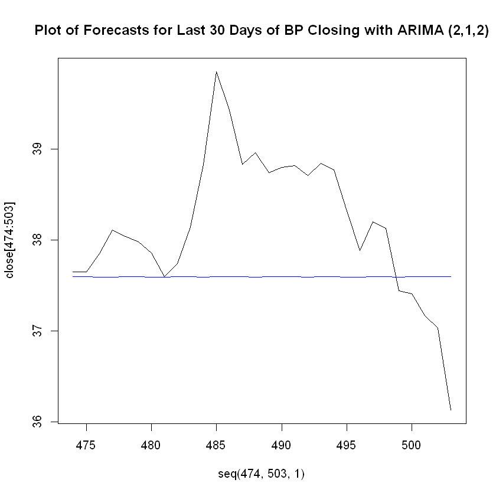

```r
#close up the forecast
plot(seq(474,503,1), close[474:503],type = 'l', xlim = c(474,503))
lines(seq(474,503), dif.fore1$f, col = 'blue')
title("Plot of Forecasts for Last 30 Days of BP Closing with ARIMA (2,1,2)")
```

#### Figure 11: Close up Plot of Forecasts for Last 30 Days of BP Closing Stock Price with ARIMA (2,1,2). The forecast does not do a great job of forecasting against the actual closing prices

Forecasting errors can be evaluated in terms of Average Square Error (ASE). Lower ASE models are preferred.

$ASE = mean((Forecasted Value - Observed Actual Value)^2)$

```r
#calculate ASE for model 1 - ARIMA(2,1,2)
ASE1 = mean((dif.fore1$f - close[(length(close) - 29):length(close)])^2)
ASE1
```

0.895149546218454

Back to Top

### Grid Search

Next we can utilize the a grid search function to attempt to find the best fitting model for the BP stock data.

The `auto.arima()` function in the R package `fpp2` uses a variation of the Hyndman-Khandakar algorithm, which combines unit root tests, minimization of the AICs and MLE to obtain an ARIMA model.

1. The number of differences $0≤d≤2$ is determined using repeated KPSS tests.
2. The values of $p$ and $q$ are then chosen by minimising the AICc after differencing the data $d$ times. Rather than considering every possible combination of $p$ and $q$, the algorithm uses a stepwise search to traverse the model space.

   a. Four initial models are fitted:
   - ARIMA(0,$d$,0),
   - ARIMA(2,$d$,2),
   - ARIMA(1,$d$,1),
   - ARIMA(0,$d$,1).

     A constant is included unless $d = 2$. If $d \leq 1$, an additional model is also fitted: ARIMA(0,$d$,0) without a constant.

   b. The best model (with the smallest AICc value) fitted in step (a) is set to be the “current model”.

   c. Variations on the current model are considered:
   - vary $p$ and/or $q$ from the current model by $±$ 1;
   - include/exclude $c$ from the current model. The best model considered so far (either the current model or one of these variations) becomes the new current model.

   d. Repeat Step 2(c) until no lower AICc can be found.

For this grid search, the default maximum values of $p$, $q$ and $d$ will be increased so that more models are searched.

```r
#grid search function of fpp2 package
auto.arima(close.dif, max.p = 8, max.q = 5, max.d=3)
```

```
Series: close.dif
ARIMA(2,0,1) with zero mean

Coefficients:
          ar1      ar2     ma1
      -0.3148  -0.0400  0.2388
s.e.   0.5719   0.0595  0.5705

sigma^2 estimated as 0.2785:  log likelihood=-389.94
AIC=787.89   AICc=787.97   BIC=804.76
```

#### The grid search suggests an ARIMA(2,0,1) on the differenced data, which is also a ARIMA(2,1,1) on the original data.

#### Next, an estimate will be created using the suggested model, as it was on the manually searched model 1.

```r
#create estimate of suggested ARIMA(2,1,1) model
dif.est4 = est.arma.wge(close.dif, p=2, q=1)
```

```
Coefficients of Original polynomial:
-0.3278 -0.0411

Factor                 Roots                Abs Recip    System Freq
1+0.3278B+0.0411B^2   -3.9830+-2.9051i      0.2028       0.3997
```

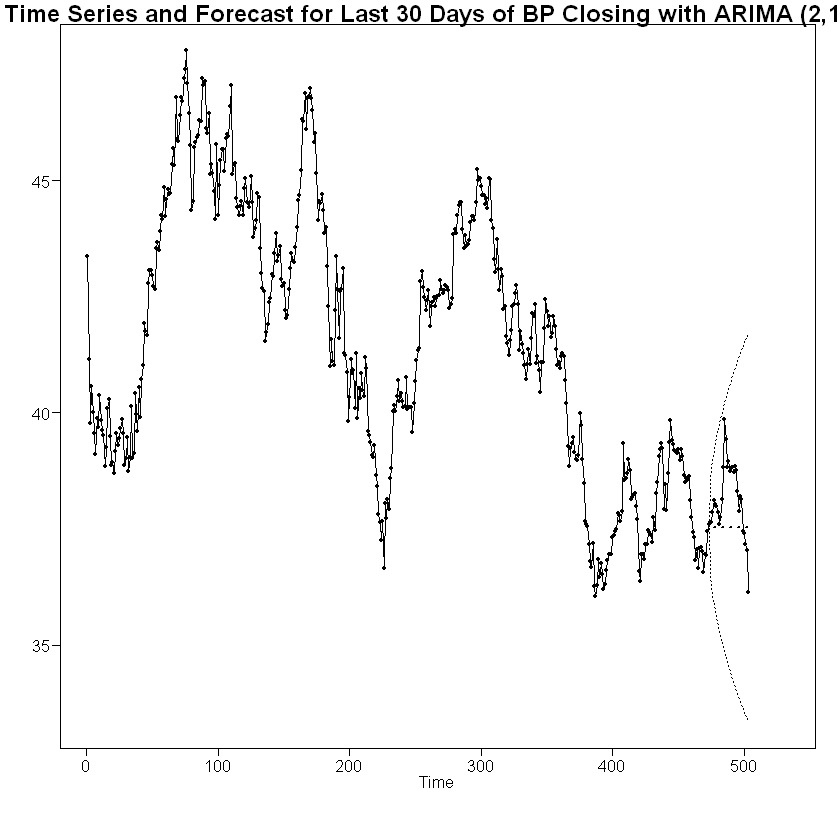

```r
#forecasting based on suggested grid search model ARIMA(2,1,1)
dif.fore4 = fore.aruma.wge(close, phi = dif.est4$phi, d = 1, n.ahead = 30, lastn = T, limits = T)
title("Time Series and Forecast for Last 30 Days of BP Closing with ARIMA (2,1,1)")
```

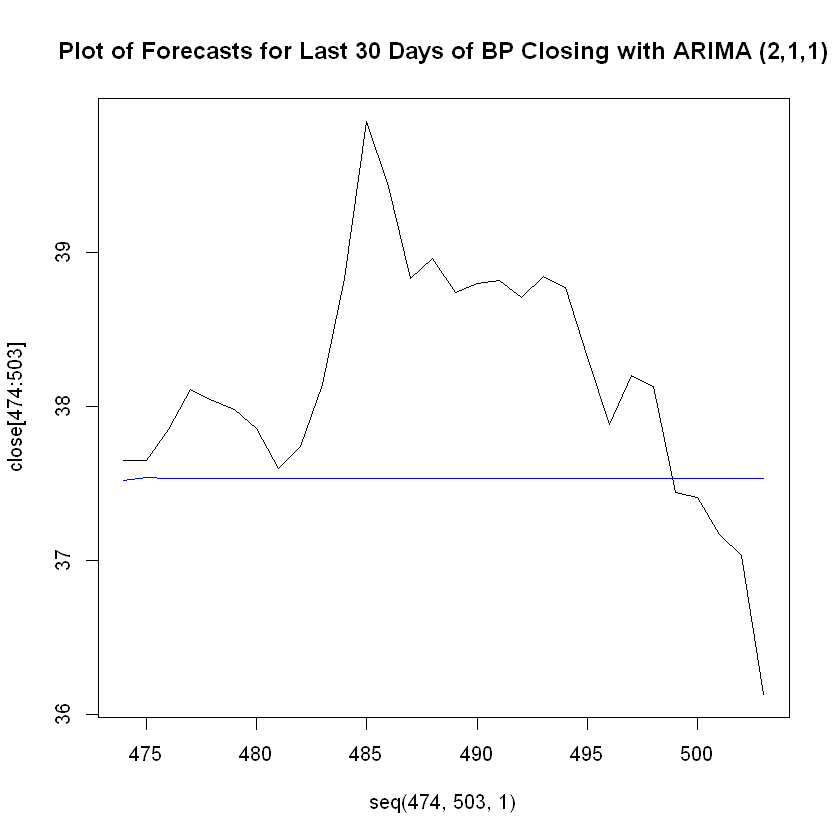

```r
#close up the forecast
plot(seq(474,503,1), close[474:503],type = 'l', xlim = c(474,503))
lines(seq(474,503), dif.fore4$f, col = 'blue')
title("Plot of Forecasts for Last 30 Days of BP Closing with ARIMA (2,1,1)")
```

```r
#average square error for (2,1,1)
ASE4= mean((dif.fore4$f - close[(length(close) - 29):length(close)])^2)
ASE4
```

0.967104064727587

#### Using `auto.arima()` a plot of the future $n$ values can also be easily created.

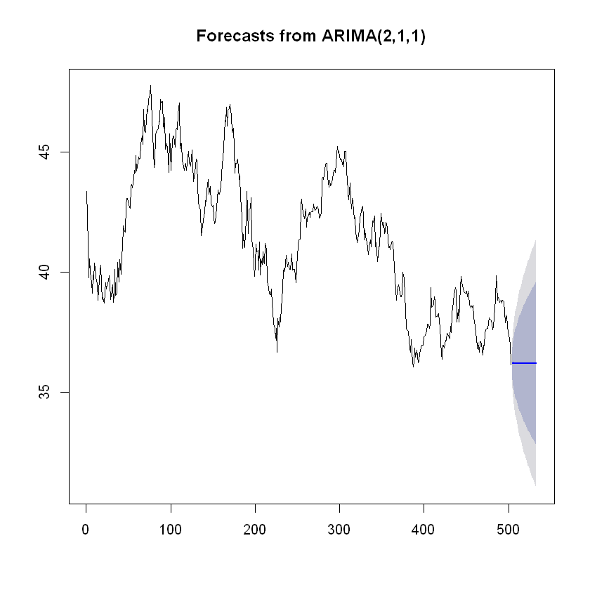

```r
#plot of future 30 days
plot(forecast(auto.arima(close, max.p = 8, max.q = 5, max.d=3),h=30))
```

#### Figure 14: Plot of Forecasts for Next 30 Days of BP Closing Stock Price with ARIMA (2,1,1). The forecast only seems to repeat the same value.

### Summary of manual model search and grid search with `auto.arima()`.

| Manual Selection | Grid Search |
| --- | --- |
| ARIMA(2,1,2) | ARIMA(2,1,1) |
| ASE = 0.8951 | ASE = 0.9671 |

Back to Top

### Conclusion

Analyzing stock data is no easy task. The ARIMA models tried, both manual and grid searched, in this case study did not seem to do an adequate job of forecasting the actual values of the BP clsoing prices. This may be because of an error in the modelling, such as a seasonal term that was not accounted for. Or it indicates that economics is a complicated field with many other variables at work such as political environment, interest rates, and supply and demand. In the future, a multivariate model could be used that might better estimate the daily closing prices.

Back to Top

### References

- https://otexts.com/fpp2/arima-r.html
- https://towardsdatascience.com/significance-of-acf-and-pacf-plots-in-time-series-analysis-2fa11a5d10a8
- https://www.itl.nist.gov/div898/handbook/pmc/section4/pmc442.htm
- https://www.rdocumentation.org/packages/forecast/versions/8.11/topics/auto.arima